# Przewidywanie dotyczące zatwierdzenia zgody na posiadanie karty kredytowej

Gabriela Maślanka, Mateusz Mulka, Karolina Gajewska, Karina Krotkiewicz

**Informatyka i Ekonometria**

W projekcie wykorzystano dane zawierające oczyszczoną wersję danych z repozytorium systemów uczących się po zatwierdzeiu kart kredytowych. Zmienne objaśniające, na których oparto badanie to:  
-**Gender** - płeć  
-**Age** - wiek  
-**Debt** - dług  
-**Married** - status małżeński  
-**BankCustomer** - klient banku  
-**Industry** - miejsce zatrudnienia  
-**Ethnicity**- pochodzenie etniczne  
-**YearsEmployed**- lata zatrudnienia  
-**PriorDefault** - wcześniejsze zadłużenia  
-**Employed** - status zatrudnienia  
-**CreditScore** - zdolność kredytowa  
-**DriversLicence** - posiadanie prawa jazdy  
-**Citizen** - sposób nabycia obywatelstwa  
-**ZipCode** - kod pocztowy  
-**Income** - dochód Zmienną objaśnianą jest Approved, czyli wspominane wcześniej zatwierdzenie, zgoda na posiadanie karty kredytowej.

**Zainstalowano pomocne przy pracy pakiety**

```r
library(tidyverse)
library(magrittr)
```

```r
library(dplyr)
library(ggplot2)
```

### Importowanie i przygotowanie danych z pliku

```r
data <- read.csv("data.csv")%>%
  select(-ZipCode)
summary(data)
```

```
##      Gender            Age             Debt           Married
##  Min.   :0.0000   Min.   :13.75   Min.   : 0.000   Min.   :0.0000
##  1st Qu.:0.0000   1st Qu.:22.67   1st Qu.: 1.000   1st Qu.:1.0000
##  Median :1.0000   Median :28.46   Median : 2.750   Median :1.0000
##  Mean   :0.6957   Mean   :31.51   Mean   : 4.759   Mean   :0.7609
##  3rd Qu.:1.0000   3rd Qu.:37.71   3rd Qu.: 7.207   3rd Qu.:1.0000
##  Max.   :1.0000   Max.   :80.25   Max.   :28.000   Max.   :1.0000
##   BankCustomer      Industry          Ethnicity         YearsEmployed
##  Min.   :0.0000   Length:690         Length:690         Min.   : 0.000
##  1st Qu.:1.0000   Class :character   Class :character   1st Qu.: 0.165
##  Median :1.0000   Mode  :character   Mode  :character   Median : 1.000
##  Mean   :0.7638                                         Mean   : 2.223
##  3rd Qu.:1.0000                                         3rd Qu.: 2.625
##  Max.   :1.0000                                         Max.   :28.500
##   PriorDefault       Employed       CreditScore   DriversLicense
##  Min.   :0.0000   Min.   :0.0000   Min.   : 0.0   Min.   :0.000
##  1st Qu.:0.0000   1st Qu.:0.0000   1st Qu.: 0.0   1st Qu.:0.000
##  Median :1.0000   Median :0.0000   Median : 0.0   Median :0.000
##  Mean   :0.5232   Mean   :0.4275   Mean   : 2.4   Mean   :0.458
##  3rd Qu.:1.0000   3rd Qu.:1.0000   3rd Qu.: 3.0   3rd Qu.:1.000
##  Max.   :1.0000   Max.   :1.0000   Max.   :67.0   Max.   :1.000
##    Citizen              Income            Approved
##  Length:690         Min.   :     0.0   Min.   :0.0000
##  Class :character   1st Qu.:     0.0   1st Qu.:0.0000
##  Mode  :character   Median :     5.0   Median :0.0000
##                     Mean   :  1017.4   Mean   :0.4449
##                     3rd Qu.:   395.5   3rd Qu.:1.0000
##                     Max.   :100000.0   Max.   :1.0000
```

```r
data <- data[complete.cases(data),]
```

Zamiana zmiennych na faktory w celu reprezentacji zmiennych kategorycznych w modelu: Najpierw zajmujemy się kolumną Industry, zamieniamy ją na faktory.

```r
table(data$Industry)
```

```
##
## CommunicationServices ConsumerDiscretionary       ConsumerStaples
##                    38                    59                    54
##             Education                Energy            Financials
##                    25                   146                    51
##            Healthcare           Industrials InformationTechnology
##                    53                    64                    41
##             Materials           Real Estate              Research
##                    78                    30                    10
##             Transport             Utilities
##                     3                    38
```

```r
data<-data %>% mutate(Industry=as.factor(Industry))
```

Następnie przechodzimy do wartości z kolumny Citizen, wyświetlamy je sobie, z racji że wartości ByOtherMeans i Temporary jest dosyć mało łączymy je w jeden poziom o nazwie Other.

```r
table(data$Citizen)
```

```
##
##      ByBirth ByOtherMeans    Temporary
##          625           57            8
```

```r
data<-data %>% mutate(Citizen=as.vector(Citizen))
data<-data%>%mutate(Citizen = if_else(Citizen=="Temporary", "Other", Citizen))
data<-data%>%mutate(Citizen = if_else(Citizen=="ByOtherMeans", "Other", Citizen))
data<-data %>% mutate(Citizen=as.factor(Citizen))
table(data$Citizen)
```

```
##
## ByBirth   Other
##     625      65
```

Tak samo postępujemy z kolumną Ethnicity, łączymy te których jest najmniej aby poziomy miały stosunkowo podobną ilość wartości.

```r
table(data$Ethnicity)
```

```
##
##  Asian  Black Latino  Other  White
##     59    138     57     28    408
```

```r
data<-data%>%mutate(Ethnicity = if_else(Ethnicity=="Latino", "Other", Ethnicity))
data<-data%>%mutate(Ethnicity = if_else(Ethnicity=="Asian", "Other", Ethnicity))
table(data$Ethnicity)
```

```
##
## Black Other White
##   138   144   408
```

```r
data<-data %>% mutate(Ethnicity=as.factor(Ethnicity))
```

Sprawdzamy jak rozkładają się wartości w kolumnie Married.

```r
table(data$Married)
```

```
##
##   0   1
## 165 525
```

Dodajemy kolumnę Nr aby nasze wiersze były ponumerowane.Numery są nam potrzebne aby podzielić nasz projekt losowo w taki sposób, aby wartości się nie powtarzały.

```r
data$Nr<-c(1:nrow(data))
```

# Tworzenie modelu

Na początku dzielimy dane na zbiór treningowy i testowy w proporcji 80% i 20%.

```r
train<-data%>%slice_sample(prop=0.8)
test<-data%>%filter(!(Nr %in% train$Nr))
```

```r
model<-glm(Approved ~Age+Debt+Married+BankCustomer+Industry+YearsEmployed+Employed+CreditScore+Citizen+Income,
           family=binomial(link='logit'), train)
model
```

```
##
## Call:  glm(formula = Approved ~ Age + Debt + Married + BankCustomer +
##     Industry + YearsEmployed + Employed + CreditScore + Citizen +
##     Income, family = binomial(link = "logit"), data = train)
##
## Coefficients:
##                   (Intercept)                            Age
##                    -2.920e+00                      1.503e-02
##                          Debt                        Married
##                     4.922e-02                     -1.221e+01
##                  BankCustomer  IndustryConsumerDiscretionary
##                     1.280e+01                     -5.363e-01
##       IndustryConsumerStaples              IndustryEducation
##                     6.048e-02                      7.856e-03
##                IndustryEnergy             IndustryFinancials
##                     2.678e-01                      1.143e-01
##            IndustryHealthcare            IndustryIndustrials
##                    -3.087e+00                      5.211e-01
## IndustryInformationTechnology              IndustryMaterials
##                     1.305e+00                      6.940e-01
##           IndustryReal Estate               IndustryResearch
##                    -3.066e-01                      8.404e-02
##             IndustryTransport              IndustryUtilities
##                    -3.474e-02                      2.011e+00
##                 YearsEmployed                       Employed
##                     1.841e-01                      9.550e-01
##                   CreditScore                   CitizenOther
##                     1.723e-01                      5.272e-01
##                        Income
##                     4.866e-04
##
## Degrees of Freedom: 551 Total (i.e. Null);  529 Residual
## Null Deviance:       760.3
## Residual Deviance: 484   AIC: 530
```

Z powodu wielu poziomów zmiennej Industry patrzymy jak rozkłada się prawdopodobieństwo przyznania karty w zależności od poziomu Industry.

```r
df<-data.frame(data$Industry, data$Approved)
aggregate(df$data.Approved,list(df$data.Industry), FUN=mean )
```

```
##                  Group.1         x
## 1  CommunicationServices 0.4210526
## 2  ConsumerDiscretionary 0.2372881
## 3        ConsumerStaples 0.3518519
## 4              Education 0.5600000
## 5                 Energy 0.4520548
## 6             Financials 0.2745098
## 7             Healthcare 0.1320755
## 8            Industrials 0.5156250
## 9  InformationTechnology 0.7073171
## 10             Materials 0.6538462
## 11           Real Estate 0.2333333
## 12              Research 0.3000000
## 13             Transport 0.6666667
## 14             Utilities 0.8421053
```

Widzimy że prawdopodobieństwa nie są podobne, więc odrzucimy tą zmienną.

Wybrałyśmy sposób selekcji zmiennych poprzez odrzucanie na podstawie istotności.

```r
model<-glm(Approved ~ .-Nr  -Industry -Age - Debt - Married - BankCustomer - Gender - Ethnicity- CreditScore -Citizen - DriversLicense,
           family=binomial(link='logit'), train)
summary(model)
```

```
##
## Call:
## glm(formula = Approved ~ . - Nr - Industry - Age - Debt - Married -
##     BankCustomer - Gender - Ethnicity - CreditScore - Citizen -
##     DriversLicense, family = binomial(link = "logit"), data = train)
##
## Deviance Residuals:
##     Min       1Q   Median       3Q      Max
## -2.1740  -0.3687  -0.3068   0.5968   2.4846
##
## Coefficients:
##                 Estimate Std. Error z value Pr(>|z|)
## (Intercept)   -3.0398684  0.2703781 -11.243  < 2e-16 ***
## YearsEmployed  0.0871737  0.0464970   1.875 0.060817 .
## PriorDefault   3.3003471  0.2959888  11.150  < 2e-16 ***
## Employed       0.9987757  0.2617311   3.816 0.000136 ***
## Income         0.0005200  0.0001525   3.409 0.000651 ***
## ---
## Signif. codes:  0 '***' 0.001 '**' 0.01 '*' 0.05 '.' 0.1 ' ' 1
##
## (Dispersion parameter for binomial family taken to be 1)
##
##     Null deviance: 760.33  on 551  degrees of freedom
## Residual deviance: 397.04  on 547  degrees of freedom
## AIC: 407.04
##
## Number of Fisher Scoring iterations: 7
```

Zmienne które nam zostały, z których będzie stworzony nasz model to YearsEmployed, PriorDefault, Employed i Income.

## Diagnostyka Modelu

```r
cor(train[,c("Age","Debt","YearsEmployed","Income")])
```

```
##                      Age      Debt YearsEmployed     Income
## Age           1.00000000 0.1652307     0.3771648 0.01835441
## Debt          0.16523070 1.0000000     0.3090230 0.13901041
## YearsEmployed 0.37716477 0.3090230     1.0000000 0.04828810
## Income        0.01835441 0.1390104     0.0482881 1.00000000
```

Wartości są dosyć niskie, czyli korelacja jest dosyć słaba.

Sprawdzamy czy istnieje liniowa zależność.

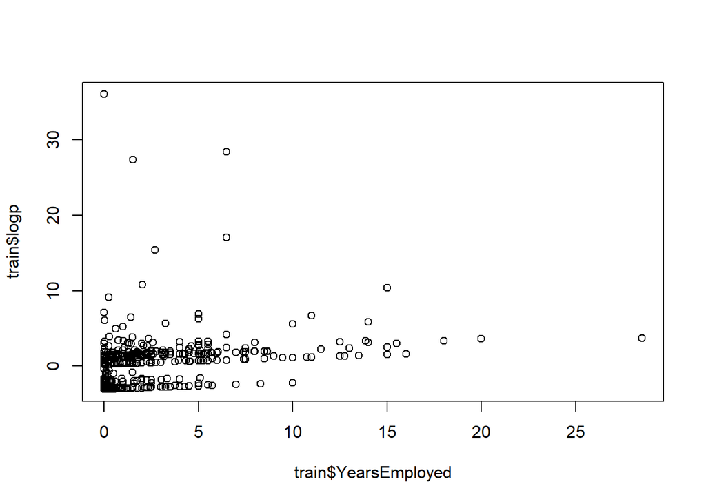

```r
prediction<-predict(model,type="response")
train$logp<-log(prediction/(1-prediction))
plot(train$YearsEmployed, train$logp)
```

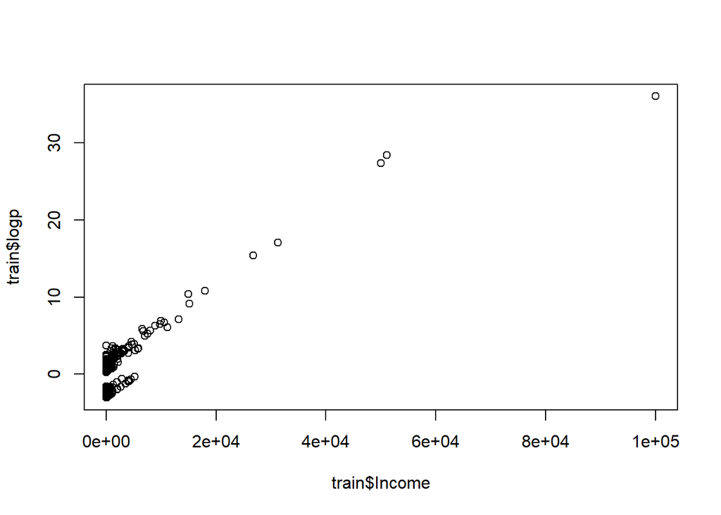

```r
plot(train$Income, train$logp)
```

Wykonujemy predykcje dla danych ze zbioru treningowego aby zobaczyć w ilu przypadkach model zadziałał prawidłowo.

```r
train_prediction<- ifelse(prediction>=0.5,1,0)
table(train_prediction, train$Approved)
```

```
##
## train_prediction   0   1
##                0 241  20
##                1  61 230
```

Następnie wykojemy predykcje na zbiorze testowym

```r
test_prediction<-predict(model,test, type = 'response')

test_prediction<- ifelse(test_prediction>=0.5,1,0)
```

Następnie wyświetlamy wyniki:

```r
table = table(test_prediction, test$Approved)
Acc = (table[1,1]+ table[2,2])/sum(table)

Sen<- table[2,2]/sum(table[,2])

Spec<- table[1,1]/sum(table[,1])
table
```

```
##
## test_prediction  0  1
##               0 64  2
##               1 17 55
```

```r
Acc
```

```
## [1] 0.8623188
```

```r
Sen
```

```
## [1] 0.9649123
```

```r
Spec
```

```
## [1] 0.7901235
```

Widzimy, że wartości są dość duże, jest to satysfakcjonujący nas wynik.